# Actividad 3

## 1.11 Hallazgos en mapas

**Predicción de casos por 10 mil habitantes**

```r
gwr_sf = st_as_sf(m.gwr2$SDF)
gwr_sf$y_predicted <- gwr_sf$yhat
tm_shape(gwr_sf) +
  tm_polygons("y_predicted",
              title="\nPredicción de Casos por 10 Mil Habitantes")
```

```
## Variable(s) "y_predicted" contains positive and negative values, so midpoint is set to 0. Set midpoint = NA to show the full spectrum of the color palette.
```

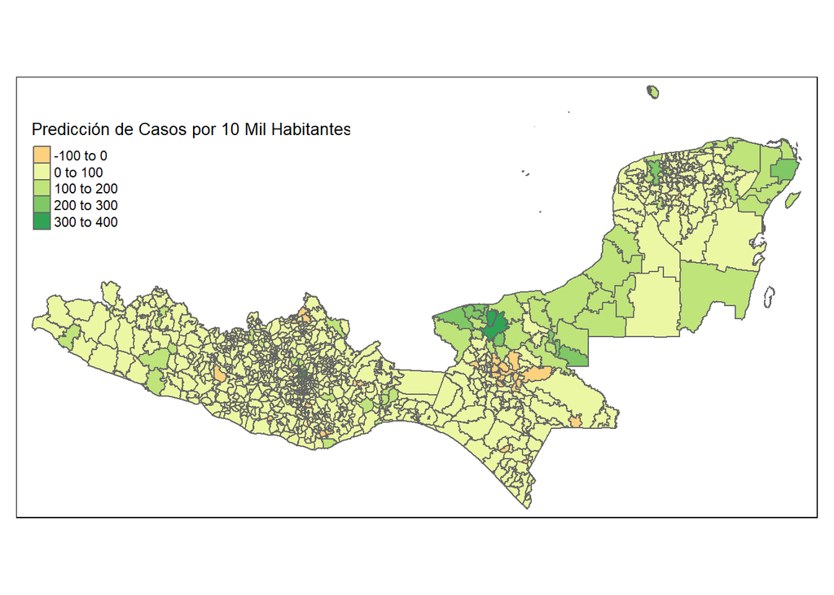

En este caso podemos observar en el mapa la predicción del reporte de casos de covid según nuestro segundo modelo GWR. Podemos observar que según el modelo las zonas de Chiapas y Oaxaca, sobre todo Chiapas, son aquellas donde se reportarán menos casos de Covid. Las zonas de Campeche, Quinta Roo y Yucatán son las que se encuentran en un punto “medio”. Finalmente, Tabasco es la zona donde se predicen más casos de covid, habiendo incluso un municipio con más de 350 casos por 10 mil habitantes.

**Predicción de R2 local**

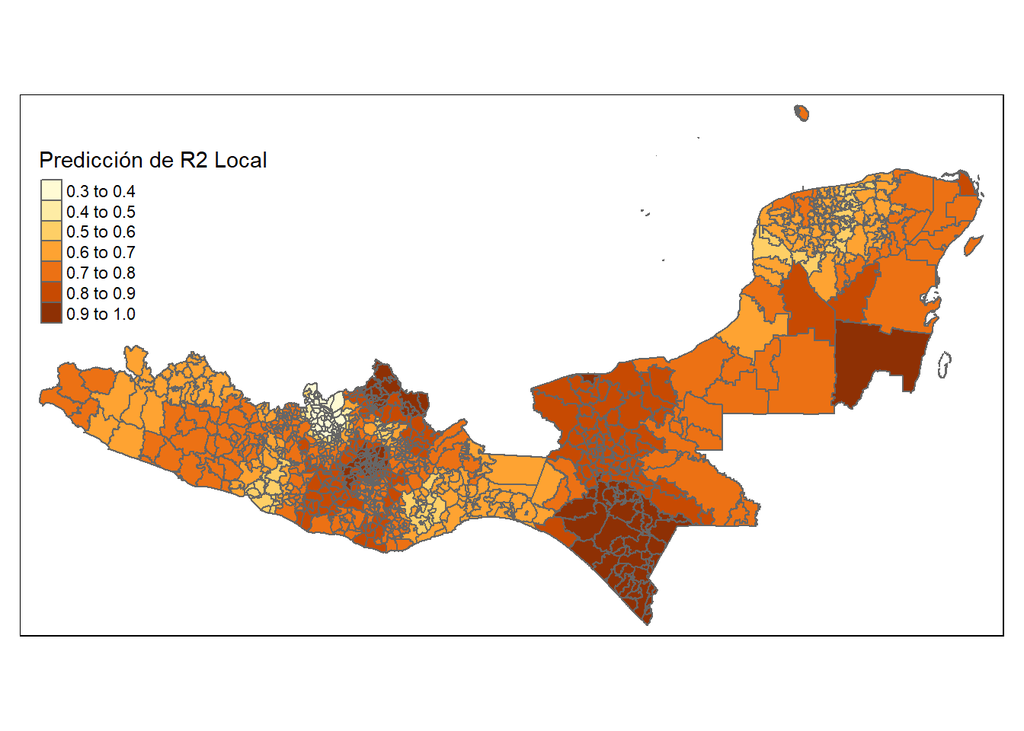

```r
tm_shape(gwr_sf) +
  tm_polygons("Local_R2",
              title="\nPredicción de R2 Local")
```

En el mapa podemos observar la predicción de la R2 local. En este podemos ver que Chiapas es el estado donde nuestro modelo explicar mejor la varianza al tener en el sur del estado hasta arriba del 90%. En cuanto al resto, en su mayoría oscila entre el 60 y el 75%. Usando esta métrica podemos ver en qué municipios nuestras estimaciones serán más confiables, aunque se deben tomar en cuenta también otras métricas.

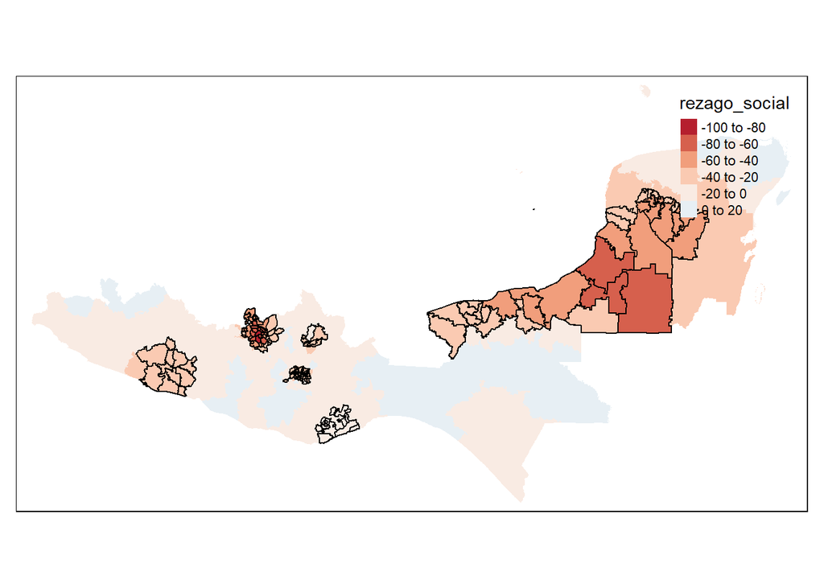

```r
tval = gwr_sf %>% dplyr::select(all_of("rezago_social_TV")) %>% st_drop_geometry()
signif = tval < -1.96 | tval > 1.96
# map the counties
tm_shape(gwr_sf) +
  tm_fill("rezago_social",midpoint = 0) + tm_style("col_blind")+
  tm_layout(legend.position = c("right","top"))+
  # now add the tvalues layer
  tm_shape(gwr_sf[signif,]) + tm_borders()
```

En este mapa tomamos en cuenta los t-values de rezago social para predecir los casos. Podemos ver que los estados donde el rezago social es significativo para predecir es principalmente en Tabasco y Campeche. Acá podemos ver que según nuestro modelo mientras más aumente el rezago social en estos municipios menos casos serán reportados.

**Predicción de Población sin acceso a seguridad social**

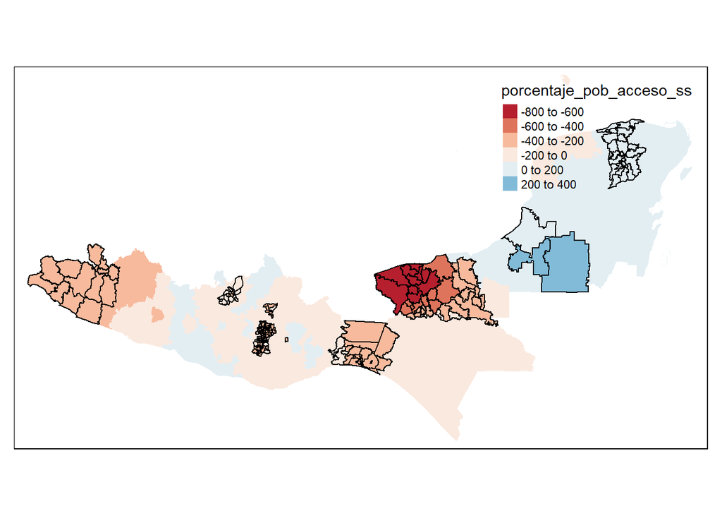

```r
tval = gwr_sf %>% dplyr::select(all_of("porcentaje_pob_acceso_ss_TV")) %>% st_drop_geometry()
signif = tval < -1.96 | tval > 1.96
# map the counties
tm_shape(gwr_sf) +
  tm_fill("porcentaje_pob_acceso_ss",midpoint = 0) + tm_style("col_blind")+
  tm_layout(legend.position = c("right","top"))+
  # now add the tvalues layer
  tm_shape(gwr_sf[signif,]) + tm_borders()
```

**Predicción de Hospitales Privados por 10 Mil Habitantes**

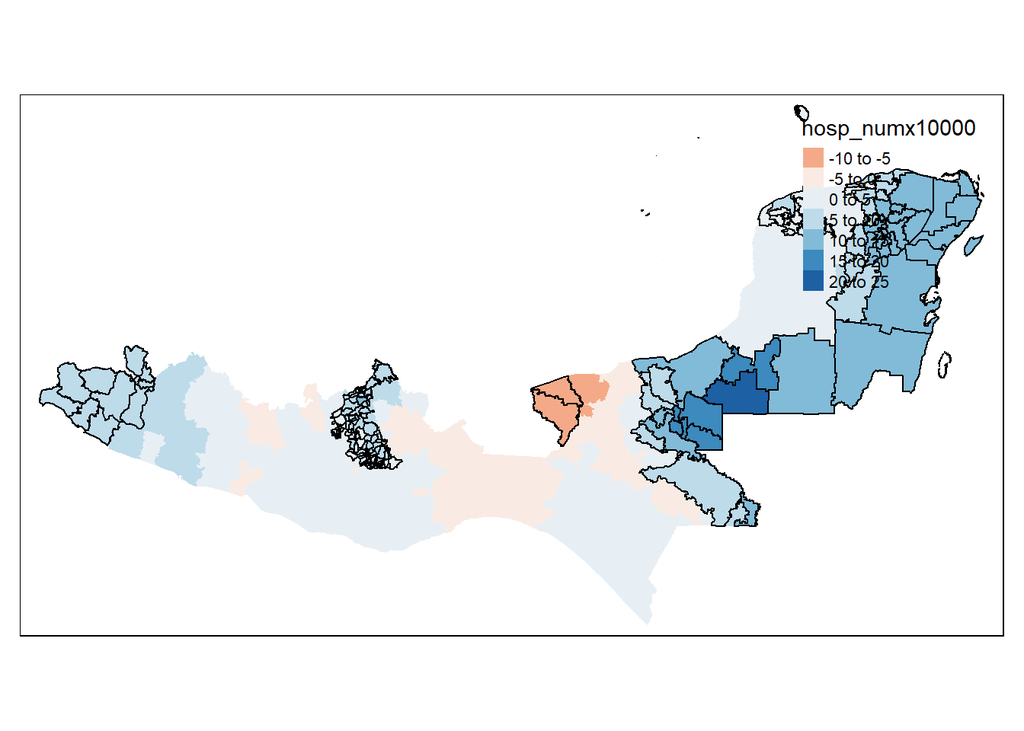

```r
tval = gwr_sf %>% dplyr::select(all_of("hosp_numx10000_TV")) %>% st_drop_geometry()
signif = tval < -1.96 | tval > 1.96
# map the counties
tm_shape(gwr_sf) +
  tm_fill("hosp_numx10000",midpoint = 0) + tm_style("col_blind")+
  tm_layout(legend.position = c("right","top"))+
  # now add the tvalues layer
  tm_shape(gwr_sf[signif,]) + tm_borders()
```

En este mapa vemos que existen varios clústers, el principal ocupando parte de Campeche, Tabasco, Yucatán y Quintana Roo. En este clúster vemos que el t-value es significativo y que predice que cuando los hospitales privados aumenten también aumentarán los casos de covid reportados. Esto tiene sentido ya que si existen más instituciones que diagnostiquen entonces también los casos que se reporten aumentarán.

## 1.12 Variables Significativas y estrategia

### 1.12.2 Estrategias

Estrategia 1: Basado en las variables significativas y en el sistema actual de salud en México se puede identificar que aumentar la infraestructura en instituciones especialmente en las regiones rurales, fomentar la educación para la salud y mejorar la calidad son algunas de las problemáticas en el sistema de salud. Se recomienda generar un plan de salud en donde los mexicanos pueden tener acceso a este sistema de salud, aunque recordemos que ha habido planes de salud que no han sido satisfactorios, el gobierno también se puede apoyarse en esas fallas que han tenido para que en este no suceda y poder intentar que este plan de salud sea lo más satisfactorio posible. Así mismo, que se concentre en buscar lugares estratégicos para tener un centro médico donde las personas tengan un acceso fácil a este y su tiempo de traslado no sea tan tardado.

Estrategia 2: Podemos observar en los mapas que existen ciertos municipios donde el acceso a servicios de seguridad social y el número de hospitales privados determinan en gran medida el reporte de casos de covid. Dado que nuestra hipótesis actual es que existen municipios donde el número de casos es bajo ya que no hay suficientes instituciones que detecten los casos actuales y los reporten. Debido a esto recomendamos que en las zonas donde el acceso es muy bajo, como algunos municipios de Chiapas y Oaxaca, se implementen estrtegias como módulos de paoyo y detección al Covid temporales y/o transporte hacia municipios cercanos con instituciones, así como kits de detección. De esta manera, aunque el acceso a salud no se solucione, se tendrá un mayor seguimiento a los casos existentes.